# Thera_Bank Project_Final

### Income_Cateogry vs Credit_Limit vs Education_Level

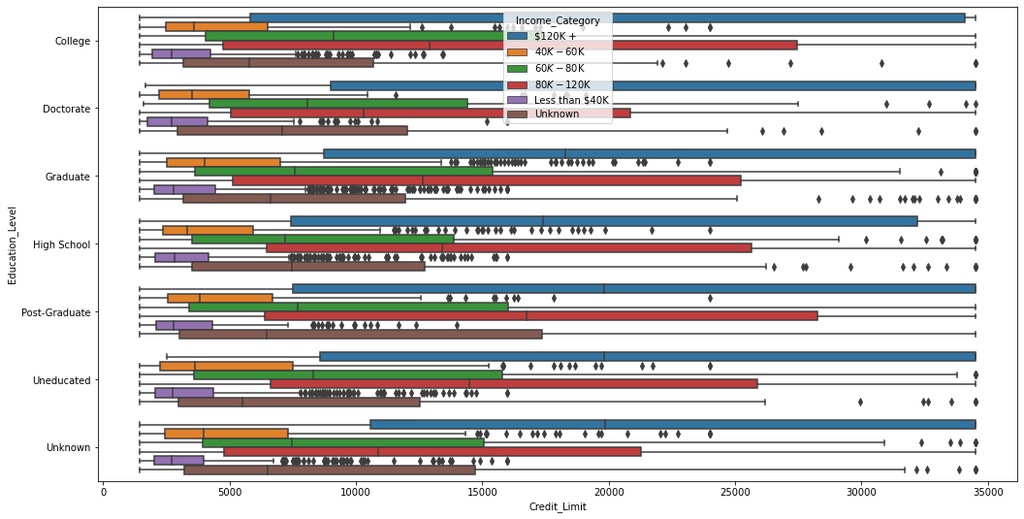

```python
plt.figure(figsize=(17,9))
sns.boxplot(y="Education_Level",x="Credit_Limit",data=df,hue='Income_Category')
plt.savefig('TriPlt_IC_CL_EL.png')
plt.show()
```

### Insights

- Across all Educational Levels the Highest income category of $120k+ attracts the highest credit limits. This clearly speaks to the higher your income, the higher your credit limit as your income secures the exposure of the bank
- This is followed by the 80k-120k > 60k-80k >Unknown> 40k-60k >less than 40K
- The management of Thera Bank should employ cordinated efforts, resources and additional value added offerings to aggressively track and trap all prospects with very reasonable to high income.

### Income Category vs Card Category vs Avg_Open_To_Buy

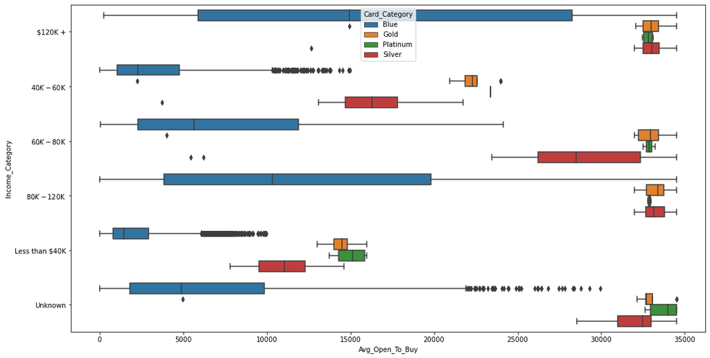

```python
plt.figure(figsize=(17,9))
sns.boxplot(y="Income_Category",x="Avg_Open_To_Buy",data=df,hue='Card_Category')
plt.savefig('TriPlt_IC_AoB_CC.png')
plt.show()
```

### Attrition_Flag vs Bank Relationship

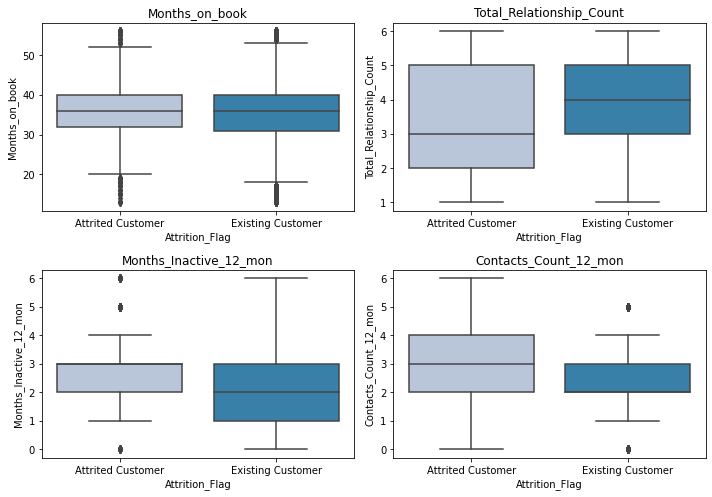

```python
cols = df[['Months_on_book','Total_Relationship_Count','Months_Inactive_12_mon', 'Contacts_Count_12_mon']].columns.tolist()
plt.figure(figsize=(10,10))

for i, variable in enumerate(cols):
                     plt.subplot(3,2,i+1)
                     sns.boxplot(df["Attrition_Flag"],df[variable],palette="PuBu")
                     plt.tight_layout()
                     plt.title(variable)

plt.savefig('Plt_AF_vs_BR.png')
plt.show()
```

### Attrition_Flag vs Transaction Volume vs Credit Details

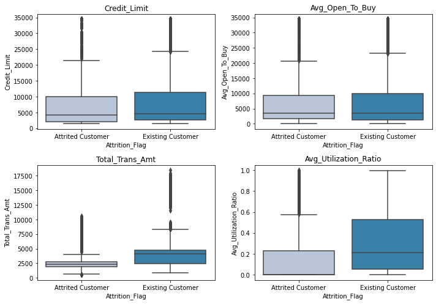

```python
cols = df[['Credit_Limit','Avg_Open_To_Buy','Total_Trans_Amt',
       'Avg_Utilization_Ratio']].columns.tolist()
plt.figure(figsize=(10,10))

for i, variable in enumerate(cols):
                     plt.subplot(3,2,i+1)
                     sns.boxplot(df["Attrition_Flag"],df[variable],palette="PuBu")
                     plt.tight_layout()
                     plt.title(variable)

plt.savefig('Plt_AF_vs_TCV.png')
plt.show()
```

### Attrition_Flag vs Customer Age vs Card Performance

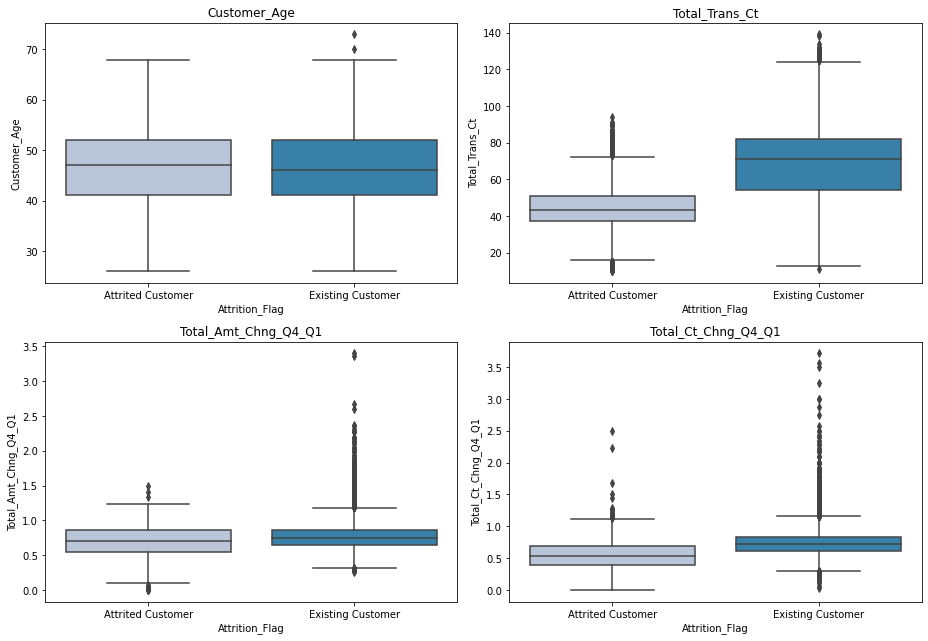

```python
cols = df[['Customer_Age','Total_Trans_Ct','Total_Amt_Chng_Q4_Q1','Total_Ct_Chng_Q4_Q1']].columns.tolist()
plt.figure(figsize=(13,13))

for i, variable in enumerate(cols):
                     plt.subplot(3,2,i+1)
                     sns.boxplot(df["Attrition_Flag"],df[variable],palette="PuBu")
                     plt.tight_layout()
                     plt.title(variable)

plt.savefig('Plt_AF_vs_CP.png')
plt.show()
```